# 3.5_DSSD_front_back_correlation_2

## 3.5 DSSD front-back Correlation(II)

### 目的：

- 对x-y的所有条进行能量刻度 (幅度归一化)
- 学习进行复杂分析的思路和方法

### 3.4节回顾

- 粒子在入射位置为：xstrip=i条、ystrip=j条，标记为$(i,j)$
- 对于入射到 $(i,j)$ ，能量沉积为E的粒子: $A_i=k_{ij}A_j+b_{ij} $

### 幅度归一化的目标是，将所有条相对于某一参考条$i$条进行刻度。

### 方法1

- 固定参考条$i$条不变，按照上述方程依次遍历所有的$j$条, 得到y面的归一化系数：$\lbrace k_{i,j},b_{i,j}\rbrace \quad ,j=0,1,...N_j $
- 对y面所有条进行刻度：$\lbrace A'_j=k_{i,j}A_j+b_{i,j} \rbrace\quad ,j=0,1,...N_j$。
- 以刻度后y面某一条$j$条作为参考条，对所有x面的条进行刻度， $ A'_{j}=k_{j,i}A_i+b_{j,i}$

经上述步骤，DSSD的$x$面和$y$面的所有条能量都归一化到第$i$参考条

- 该方法利用的是每个x条和每个y条重叠区域事件(pixel),前提是入射到每一个$(i,j)$ pixel的粒子有足够的统计。

### 方法2

- 更充分利用x-y面的关联关系
1. 在x面和y面分别寻找统计最高的条$(i_m,j_m)$
1. 以$j_m$为参考条，刻度y面一系列条： $i_{m-k_1},. ,i_{m},.,i_{m+k_2}$
1. 以刻度后的$i_{m-k_1},. ,i_{m},.,i_{m+k_2}$ 为参考条，刻度 $j_{m-k_3},.,j_{m},.,j_{m+k_4}$
1. 按照上述步骤向外推进，直到最外边缘的条的正背面关联有足够的统计做拟合。

### 下列分析以DSSD1为例，按照方法2进行刻度

备注：

生成graph程序：dssd/dssd.C, dssd.h,cut1.C,cut2.C,cut3.C

结果：刻度系数:d1cal.txt,d2cal.txt,d3cal.txt

```python
//%jsroot on
TFile *ipf = new TFile("data_16C.root");
TTree *tree = (TTree*)ipf->Get("tree");
TCanvas *c1=new TCanvas("c1","c1");
```

## 确定每个探测器正背面关联的大致范围

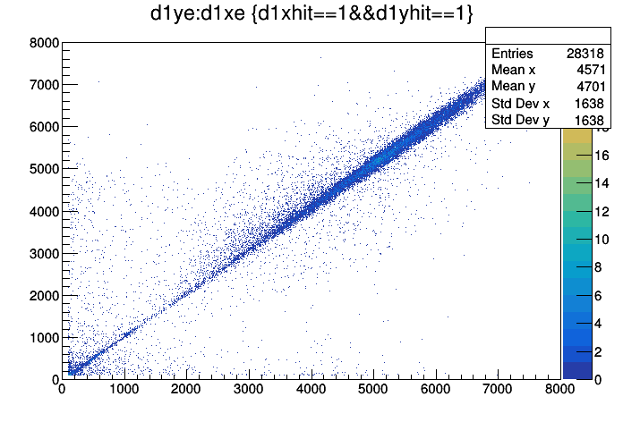

```python
tree->Draw("d1ye:d1xe>>(1000,0,8000,1000,0,8000)","d1xhit==1&&d1yhit==1","colz");
c1->Draw();
int xs,ys;//x/y strip number with maximum counts
```

- 在二维图中选择合适的区域，做TCutG，命名为cutd1xy,保存到cut1.C

[figure not shown]

```python
gROOT->Macro("cut1.C");
```

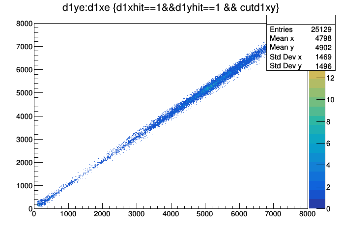

```python
tree->Draw("d1ye:d1xe>>(1000,0,8000,1000,0,8000)","d1xhit==1&&d1yhit==1 && cutd1xy","colz");
c1->Draw();
```

## 找到每个探测器x和y面计数最高条的编号

```
18 13
```

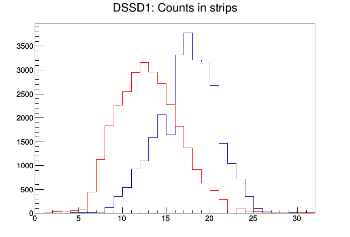

```python
THStack *hs1 = new THStack("hs1","DSSD1: Counts in strips");
tree->Draw("d1xs>>h1xs(32,0,32)","d1xhit==1 && d1yhit==1");
tree->Draw("d1ys>>h1ys(32,0,32)","d1xhit==1 && d1yhit==1");
h1ys->SetLineColor(2);
hs1->Add(h1xs);
hs1->Add(h1ys);
xs=h1xs->GetMaximumBin();
ys=h1ys->GetMaximumBin();
cout<<xs<<" "<<ys<<endl;
hs1->Draw("nostack");
c1->Draw();
```

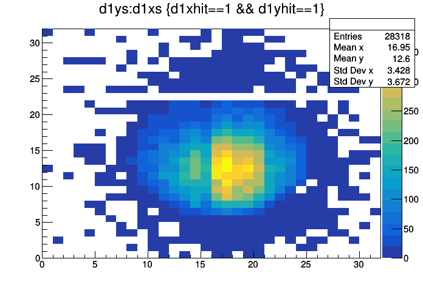

```python
tree->Draw("d1ys:d1xs>>(32,0,32,32,0,32)","d1xhit==1 && d1yhit==1","colz");
c1->Draw();
```

### 将满足所有满足条件的x-y关联事件存入ROOT文件

- 以x:12条和y:13条为例，将满足下列条件,以及在cut1范围内的所有关联事件存入TGraph *g1213

  ```
  bool bveto="d1x[11]<100 && d1x[13]<100 && d1y[12]<100 && d1y[14]<100";
  bool b1213="d1x[12]>200 && d1x[12]<8000 && d1y[13]>200&& d1y[13]<8000";
  bool bcut=bveto && b1213;
  ```

- 将所有x-y组合的TGraph 存入以gdet1.root为名的文件中

```python
//选择x-y方向条的范围，以每条计数大于1500为界限
int xrange[2]={13,21};
int yrange[2]={8,16};
```

```python
TGraph *grx[32][32];
TFile *fg=new TFile("gdet1.root");
```

```python
for(int ix=0;ix<32;ix++) {
    for(int iy=0;iy<32;iy++) {
        grx[ix][iy]=new TGraph;
        grx[ix][iy]=(TGraph*)fg->Get(Form("g%02d%02d",ix,iy));
    }
}
```

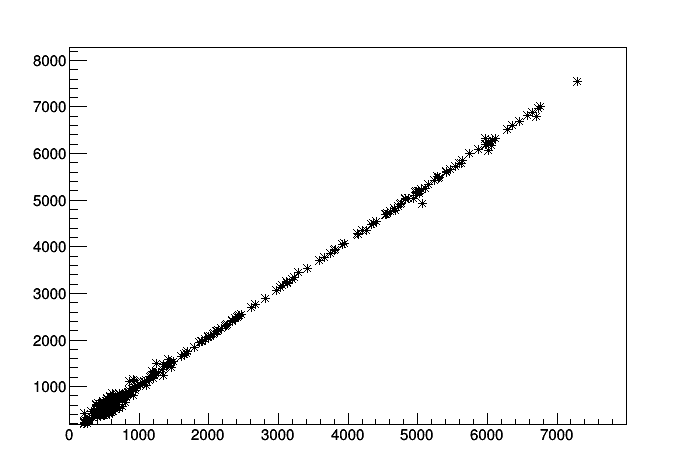

```python
grx[10][10]->Draw("A*");
c1->Draw();
```

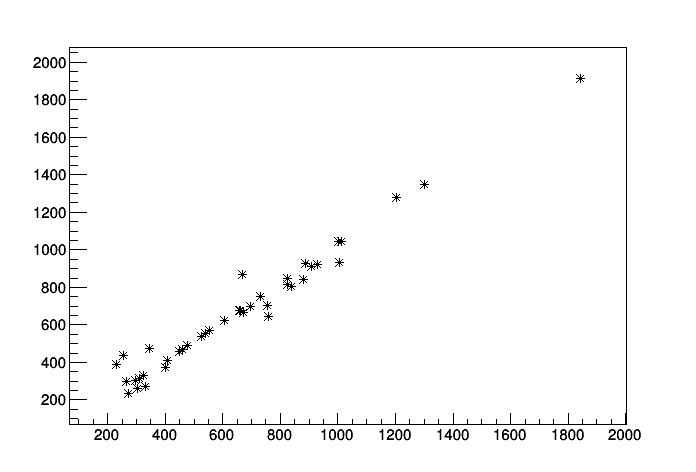

```python
grx[0][0]->Draw("A*");
c1->Draw();
```

## 1.以y:ys条为标准刻度x:xrange[0]-xrange[1]

```python
TGraph *grxc[32];
TF1 *fpa1= new TF1("fp1","pol1",200,8000);
TF1 *fpa2= new TF1("fp2","pol2",200,8000);
TH2F *hres[32];
TString shead,sout,hresname;
double par[2],par2[32][3], chi2ndf[32];
int xmax[32],Ncx[32];
```

```python
shead.Form("%4s%9s%11s%20s%16s%8s%8s","ix","p0","p1","p2","chi2/ndf","xmax","Nc");
cout<<shead<<endl;
for(int ix=xrange[0]; ix<=xrange[1]; ix++) {
    grxc[ix]=new TGraph;
    int ng=0;
    //fit with pol1 first, make new TGraph for the next fitting..
    if(grx[ix][ys]->GetN()>20) {//only fit the graph with enough statistics
        grx[ix][ys]->Fit(fpa1,"Q ROB");
        fpa1->GetParameters(&par[0]);
        for(int k=0; k<grx[ix][ys]->GetN(); k++) {
            double x=grx[ix][ys]->GetX()[k];
            double y=grx[ix][ys]->GetY()[k];
            if (abs(y-(par[0]+par[1]*x))<20) {
                grxc[ix]->SetPoint(ng,x,y);
                ng++;
            }
        }
    }
    //fit with pol2
    if(grxc[ix]->GetN()>20) {
        grxc[ix]->Fit(fpa2,"Q");
        fpa2->GetParameters(&par2[ix][0]);
        chi2ndf[ix]=fpa2->GetChisquare()/fpa2->GetNDF();
        hresname.Form("hres%02d",ix);
        hres[ix] = new TH2F(hresname,hresname,100,-50,50,1000,200,8000);
        xmax[ix]=0;
        for(int j = 0;j < grx[ix][ys]->GetN(); j++){
            double x=grx[ix][ys]->GetX()[j];
            double y=grx[ix][ys]->GetY()[j];
            if(x>xmax[ix]) xmax[ix]=x;
            x = y-(par2[ix][0]+par2[ix][1]*x+par2[ix][2]*x*x);
            hres[ix]->Fill(x,y);

        }
        Ncx[ix]=grxc[ix]->GetN();
        sout.Form("%4d%9.2f%11.6f%20e%16.2f%8d%8d"  ,ix  ,par2[ix][0]  ,par2[ix][1]  ,par2[ix][2]  ,chi2ndf[ix], xmax[ix],Ncx[ix]);
        cout<<sout<<endl;
    }
}
```

```
  ix       p0         p1                  p2        chi2/ndf    xmax      Nc
  13    -8.52   1.040038        4.564665e-07           28.29    7176     417
  14   -15.59   1.046133        6.237706e-07           29.13    7019     446
  15    -5.33   1.019887        7.216581e-07           26.37    7249     456
  16   -13.45   1.017837        4.798756e-07           19.79    7370     650
  17    -7.86   1.024728        3.959164e-07           21.47    7324     654
  18   -15.24   1.033217        3.705279e-07           21.56    7360     573
  19   -11.48   1.000385        3.764374e-07           28.16    7431     595
  20   -15.27   1.029878        4.996376e-07           22.07    7117     511
  21   -11.01   1.028210        4.244694e-07           24.53    7266     375
```

- 检查输出中xmax和Nc的值是否符合要求
  - xmax: 数据点中x的最大值，要覆盖需要刻度的幅度范围
  - Nc : 参与拟合点的数目，

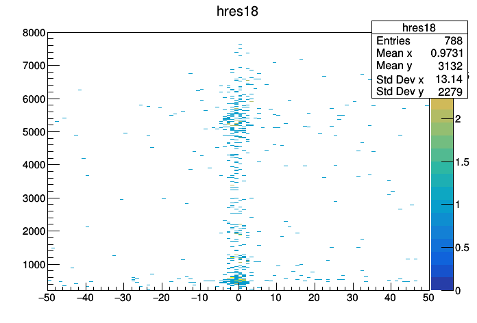

```python
hres[xs]->Draw("colz");
c1->Draw();
```

```python
TGraph *grsumx=new TGraph;
TH2F *hsumresx = new TH2F("hsumrex","hsumresx",100,-50,50,1000,200,8000);
int ngs=0;
TGraph *grsy[32];//x<->y
```

### 合并xrange范围内的数据，用残差关联图检验刻度效果

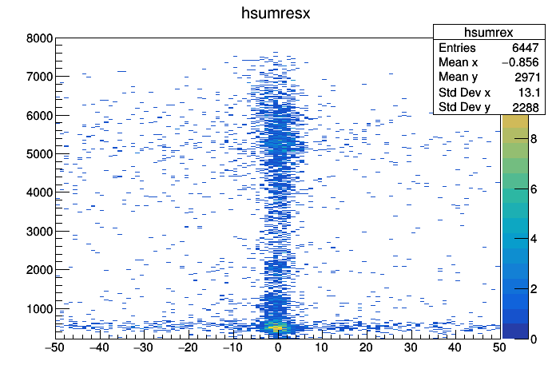

```python
hsumresx->Reset();
for(int ix=xrange[0];ix<=xrange[1];ix++) {
    for(int i=0;i<grx[ix][ys]->GetN();i++) {
        double x=grx[ix][ys]->GetX()[i];
        double y=grx[ix][ys]->GetY()[i];
        x = par2[ix][0]+par2[ix][1]*x+par2[ix][2]*x*x;
        grsumx->SetPoint(ngs,x,y);
        hsumresx->Fill(x-y,y);
        ngs++;
    }
}
hsumresx->Draw("colz");
c1->Draw();//seems OK!

//calibrate x strip, merge x strips, swap x and y for fitting
for(int iy=0;iy<32;iy++) {
    int ngy=0;
    grsy[iy]=new TGraph;
    for(int ix=xrange[0];ix<=xrange[1];ix++) {
        for(int i=0;i<grx[ix][iy]->GetN();i++) {
            double x=grx[ix][iy]->GetX()[i];
            double y=grx[ix][iy]->GetY()[i];
            x = par2[ix][0]+par2[ix][1]*x+par2[ix][2]*x*x;
            grsy[iy]->SetPoint(ngy,y,x);//swap x,y for TGraph fit, x=ky+b;
            ngy++;
        }
    }
}
```

## 2.以刻度后的xrange条为参考条，刻度y:0-31

```python
TGraph *grsyc[32];
double par2y[32][3];
TH2F *hy[32], *hresy[32];
TF1 *fpy1[32],*fpy2[32];
//TH2F *hsumresx = new TH2F("hsumrex","hsumresx",100,-50,50,1000,200,8000);
//int ngs=0;
```

```python
shead.Form("%4s%9s%11s%20s%16s%8s%8s","iy","p0","p1","p2","chi2/ndf","ymax","Nc");
cout<<shead<<endl;
for(int iy=0;iy<32;iy++) {
    TString sname;
    sname.Form("p%2dy1",iy);
    fpy1[iy]=new TF1(sname.Data(),"pol1",200,8000);
    fpy1[iy]->SetLineColor(kGray);
    int ng=0;
    grsyc[iy]=new TGraph;
    //fit with pol1 first, make new TGraph for the next fitting..
    if(grsy[iy]->GetN()>20) {
        grsy[iy]->Fit(fpy1[iy],"Q ROB");
        fpy1[iy]->GetParameters(&par[0]);
        for(int k=0; k<grsy[iy]->GetN(); k++) {
            double x=grsy[iy]->GetX()[k];
            double y=grsy[iy]->GetY()[k];
            if (abs(y-(par[0]+par[1]*x))<10) {
                grsyc[iy]->SetPoint(ng,x,y);
                ng++;
            }
        }
    }
    sname.Form("h%2dy",iy);
    hy[iy]=new TH2F(sname.Data(),sname.Data(),1000,0,8000,1000,0,8000);
    for(int i = 0;i < grsyc[iy]->GetN();++i)
        hy[iy]->Fill(grsy[iy]->GetX()[i],grsy[iy]->GetY()[i]);
    //fit with pol2
    sname.Form("p%2dy2",iy);
    fpy2[iy]=new TF1(sname.Data(),"pol2",200,8000);
    fpy2[iy]->SetLineColor(kGray);
    if(grsyc[iy]->GetN()>20) {
        grsyc[iy]->Fit(fpy2[iy],"Q");
        fpy2[iy]->GetParameters(&par2y[iy][0]);
        chi2ndf[iy]=fpy2[iy]->GetChisquare()/fpy2[iy]->GetNDF();
        hresname.Form("hresy%02d",iy);
        hresy[iy] = new TH2F(hresname,hresname,100,-50,50,1000,200,8000);
        xmax[iy]=0;
        for(int j = 0;j < grsyc[iy]->GetN(); j++)
            if(grsyc[iy]->GetX()[j]>xmax[iy]) xmax[iy]=grsyc[iy]->GetX()[j];
        for(int j = 0;j < grsy[iy]->GetN(); j++){
            double x=grsy[iy]->GetX()[j];
            double y=grsy[iy]->GetY()[j];
            x = y-(par2y[iy][0]+par2y[iy][1]*x+par2y[iy][2]*x*x);
           hresy[iy]->Fill(x,y);
        }
        Ncx[iy]=grsyc[iy]->GetN();
        sout.Form("%4d%9.2f%11.6f%20e%16.2f%8d%8d"  ,iy  ,par2y[iy][0]  ,par2y[iy][1]  ,par2y[iy][2]  ,chi2ndf[iy], xmax[iy],Ncx[iy]);
        cout<<sout<<endl;
    }
}
```

```
  iy       p0         p1                  p2        chi2/ndf    ymax      Nc
   0     8.13   0.974759        1.018100e-07            8.46    6619     564
   1     0.87   0.994902        1.445829e-08            6.85    6842     912
   2     0.77   0.990073        1.712160e-07            6.89    7476    1329
   3     5.59   0.995101        2.662928e-09            6.92    7594    1700
   4    -7.39   0.997430        1.028846e-07            6.70    7611    2012
   5     0.14   1.006330       -2.366249e-08            7.23    7601    2265
   6    -5.61   1.002322       -4.301862e-09            7.29    7481    2738
   7     3.52   1.013101       -1.374803e-07            7.06    7614    3302
   8    -7.25   1.013269       -9.086414e-08            8.02    7613    3857
   9    -4.41   0.983748       -9.627802e-08            7.68    7677    3895
  10    -3.97   1.008723       -5.220015e-08            8.16    7618    4139
  11    -0.76   1.002862       -1.510001e-07            8.65    7660    4283
  12    -2.67   1.020889       -8.062061e-08            8.27    7627    4509
  13    -0.46   1.000556       -8.025727e-08            7.87    7610    4321
```

[output cut: 17 more lines]

- y:13为参考条，拟合系数p0,p2应该接近于零，p1应接近1

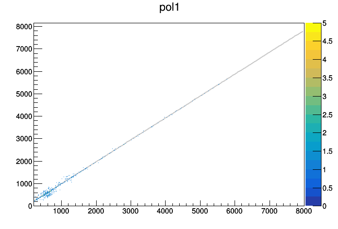

```python
fpy1[0]->Draw();
hy[0]->Draw("colz same");
c1->Draw();
```

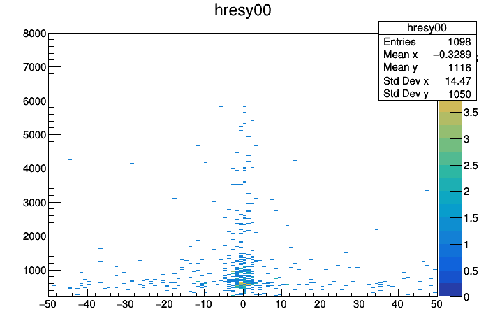

```python
hresy[0]->Draw("colz");
c1->Draw();
```

## 再次回到x条进行刻度

## 4.以刻度后的y:yrange条为参考条，刻度x:0-31

```python
int ymax[32],Ncy[32];
TGraph *grsx[32];//x<->y
TGraph *grsxc[32];
double par2x[32][3];
TH2F *hx[32], *hresx[32];
TF1 *fpx1[32],*fpx2[32];
```

```python
shead.Form("%4s%9s%11s%20s%16s%8s%8s","ix","p0","p1","p2","chi2/ndf","xmax","Nc");
cout<<shead<<endl;
for(int ix=0;ix<32;ix++) {
    int ngy=0;
    grsx[ix]=new TGraph;
    for(int iy=yrange[0];iy<=yrange[1];iy++) {
        for(int i=0;i<grx[ix][iy]->GetN();i++) {
            double x=grx[ix][iy]->GetX()[i];
            double y=grx[ix][iy]->GetY()[i];
            y = par2y[iy][0]+par2y[iy][1]*y+par2y[iy][2]*y*y;
            grsx[ix]->SetPoint(ngy,x,y);//
            ngy++;
        }
    }
    TString sname;
    sname.Form("p%2dx1",ix);
    fpx1[ix]=new TF1(sname.Data(),"pol1",200,8000);
    fpx1[ix]->SetLineColor(kGray);
    int ng=0;
    grsxc[ix]=new TGraph;
    //fit with pol1 first, make new TGraph for the next fitting..
    if(grsx[ix]->GetN()>20) {
        grsx[ix]->Fit(fpx1[ix],"Q ROB");
        fpx1[ix]->GetParameters(&par[0]);
        for(int k=0; k<grsx[ix]->GetN(); k++) {
            double x=grsx[ix]->GetX()[k];
            double y=grsx[ix]->GetY()[k];
            if (abs(y-(par[0]+par[1]*x))<10) {
                grsxc[ix]->SetPoint(ng,x,y);
                ng++;
            }
        }
    }
    sname.Form("h%2dx",ix);
    hx[ix]=new TH2F(sname.Data(),sname.Data(),1000,0,8000,1000,0,8000);
    for(int i = 0;i < grsxc[ix]->GetN();++i)
        hx[ix]->Fill(grsx[ix]->GetX()[i],grsx[ix]->GetY()[i]);
    //fit with pol2
    sname.Form("p%2dx2",ix);
    fpx2[ix]=new TF1(sname.Data(),"pol2",200,8000);
    fpx2[ix]->SetLineColor(kGray);
    if(grsxc[ix]->GetN()>20) {
        grsxc[ix]->Fit(fpx2[ix],"Q");
        fpx2[ix]->GetParameters(&par2x[ix][0]);
        chi2ndf[ix]=fpx2[ix]->GetChisquare()/fpx2[ix]->GetNDF();
        hresname.Form("hresx%02d",ix);
        hresx[ix] = new TH2F(hresname,hresname,100,-50,50,1000,200,8000);
        ymax[ix]=0;
        for(int j = 0;j < grsxc[ix]->GetN(); j++)
            if( grsxc[ix]->GetX()[j]>ymax[ix] ) ymax[ix]=grsxc[ix]->GetX()[j];
        for(int j = 0;j < grsx[ix]->GetN(); j++){
            double x=grsx[ix]->GetX()[j];
            double y=grsx[ix]->GetY()[j];
            x = y-(par2x[ix][0]+par2x[ix][1]*x+par2x[ix][2]*x*x);
           hresx[ix]->Fill(x,y);
        }
        Ncy[ix]=grsxc[ix]->GetN();
        sout.Form("%4d%9.2f%11.6f%20e%16.2f%8d%8d"  ,ix  ,par2x[ix][0]  ,par2x[ix][1]  ,par2x[ix][2]  ,chi2ndf[ix], ymax[ix],Ncy[ix]);
        cout<<sout<<endl;
    }
}
```

```
  ix       p0         p1                  p2        chi2/ndf    xmax      Nc
   0    -5.44   1.021382        6.694180e-08            8.40    5048     349
   1   -11.15   1.028288        2.049941e-07            6.77    6586     528
   2   -15.62   1.029403        2.516860e-07            6.46    6279     760
   3   -10.71   1.011694        2.366399e-07            6.01    5729    1021
   4   -15.53   1.020613        4.437918e-07            5.95    5619    1211
   5   -10.12   1.039194        2.955007e-07            6.38    6358    1342
   6   -14.40   1.034273        3.129176e-07            6.77    6015    1453
   7   -10.30   1.031251        2.338207e-07            7.54    6731    1625
   8   -14.66   1.028208        4.456058e-07            6.53    6757    1771
   9    -8.55   1.025139        4.950707e-07            7.68    7295    2007
  10   -12.36   1.041547        4.877412e-07            7.96    6966    2211
  11    -8.91   1.035695        4.728423e-07            8.58    7113    2486
  12   -13.33   1.014181        4.854816e-07            8.45    7574    2585
  13    -8.41   1.040020        4.514089e-07            9.02    7368    2941
```

[output cut: 18 more lines]

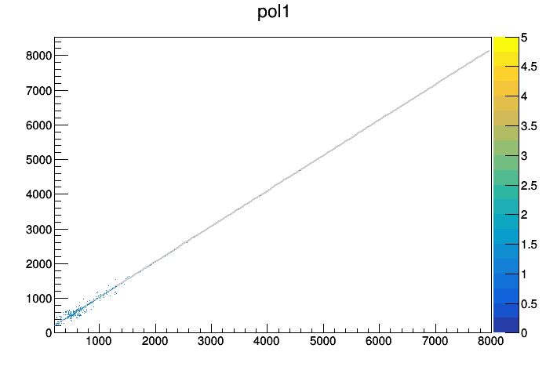

```python
fpx1[0]->Draw();
hx[0]->Draw("colz same");
c1->Draw();
```

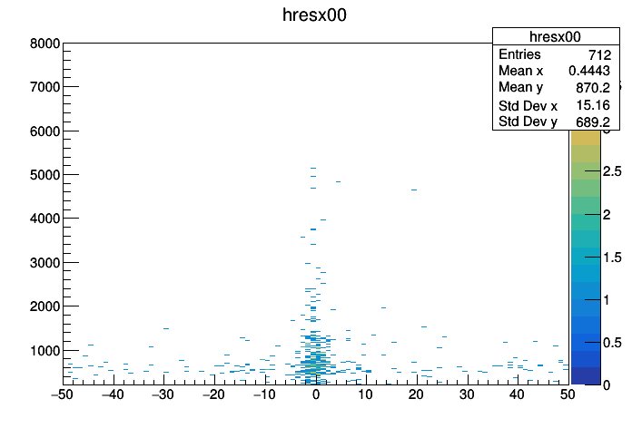

```python
hresx[0]->Draw("colz");
c1->Draw();
```

```python
TGraph *grall=new TGraph;
TH2F *hresall = new TH2F("hresall","hresall",100,-50,50,1000,200,8000);
int ngsa=0;
```

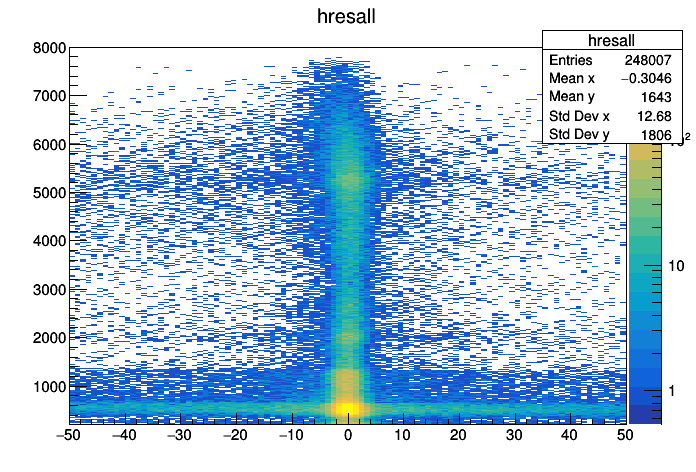

```python
hresall->Reset();
for(int ix=0;ix<32; ix++) {
   for(int iy=0;iy<32;iy++) {
    for(int i=0;i<grx[ix][iy]->GetN();i++) {
        double x=grx[ix][iy]->GetX()[i];
        double y=grx[ix][iy]->GetY()[i];
        x = par2x[ix][0]+par2x[ix][1]*x+par2x[ix][2]*x*x;
        y = par2y[iy][0]+par2y[iy][1]*y+par2y[iy][2]*y*y;
        grall->SetPoint(ngsa,x,y);
        hresall->Fill(x-y,y);
        ngsa++;
    }
   }
}
hresall->Draw("colz");
c1->SetLogz();
c1->Draw();//seems OK!
```

- 从残差分布看高能段有些偏。主要的原因是1000以下信号过多，拟合时低能段权重过大。
  - 解决方法，减少参与拟合的低能段事件数目
  - 可先将TGraph转换成TH2，再将TH2转成TGraph(TH2上每个格子上的点，在TGpaph中表达成一个点)，此时每个区域的权重完全相等。

### 刻度结果

```python
TFile *fcal=new TFile("cal_16C.root");
TTree *tr=(TTree*)fcal->Get("tree");
```

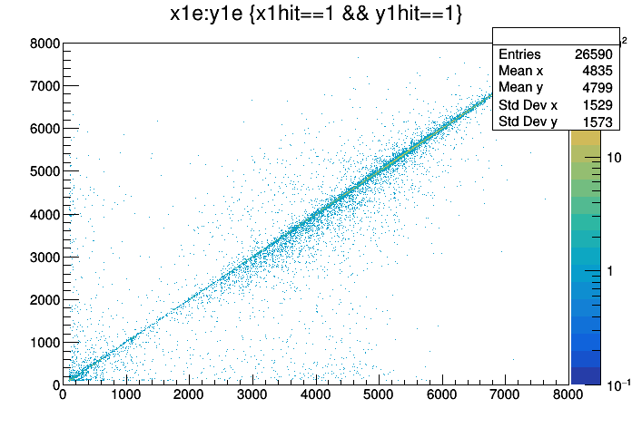

```python
tr->Draw("x1e:y1e>>(1000,0,8000,1000,0,8000)","x1hit==1 && y1hit==1","colz");
gPad->SetLogz();
c1->Draw();
```

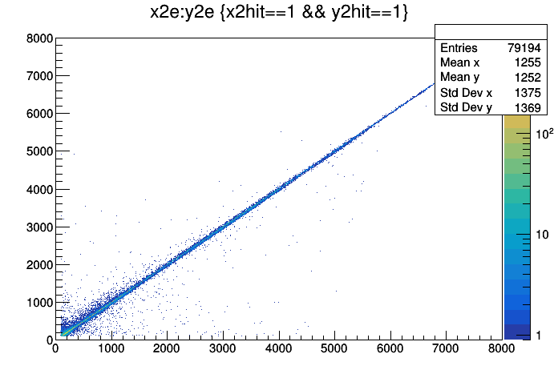

```python
tr->Draw("x2e:y2e>>(1000,0,8000,1000,0,8000)","x2hit==1 && y2hit==1","colz");
c1->Draw();
```

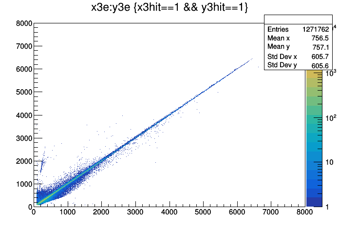

```python
tr->Draw("x3e:y3e>>(1000,0,8000,1000,0,8000)","x3hit==1 && y3hit==1","colz");
c1->Draw();
```

```python
!jupyter nbconvert 3.5_DSSD_front_back_correlation_2.ipynb --to html
```

```
[NbConvertApp] Converting notebook 3.5_DSSD_front_back_correlation_2.ipynb to html

[NbConvertApp] Writing 775125 bytes to 3.5_DSSD_front_back_correlation_2.html
```